# index.Rmd

## Variable comparison chart

I did a scatter line plot between 2 variables, and the purpose of this chart is to show the black population in jail and the black population to compare about the black population in jail and not in jail. One important observation I can derive from this chart is that even though the population is increasing drastically, but the population in jail only increase a little bit relatively. Therefore, one can reasonablly conclude that only a little out of the black population are in jail.

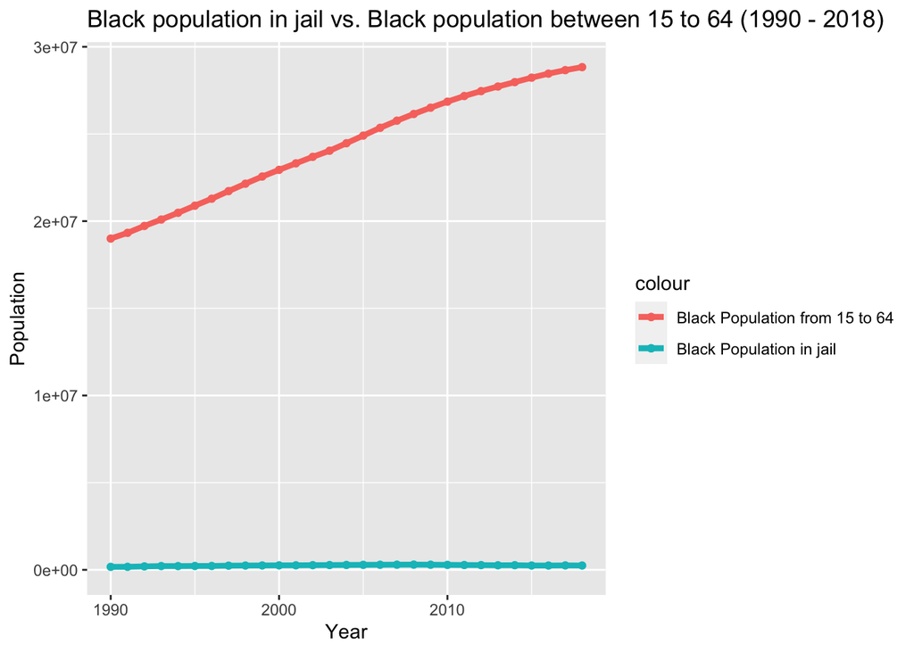

## Map

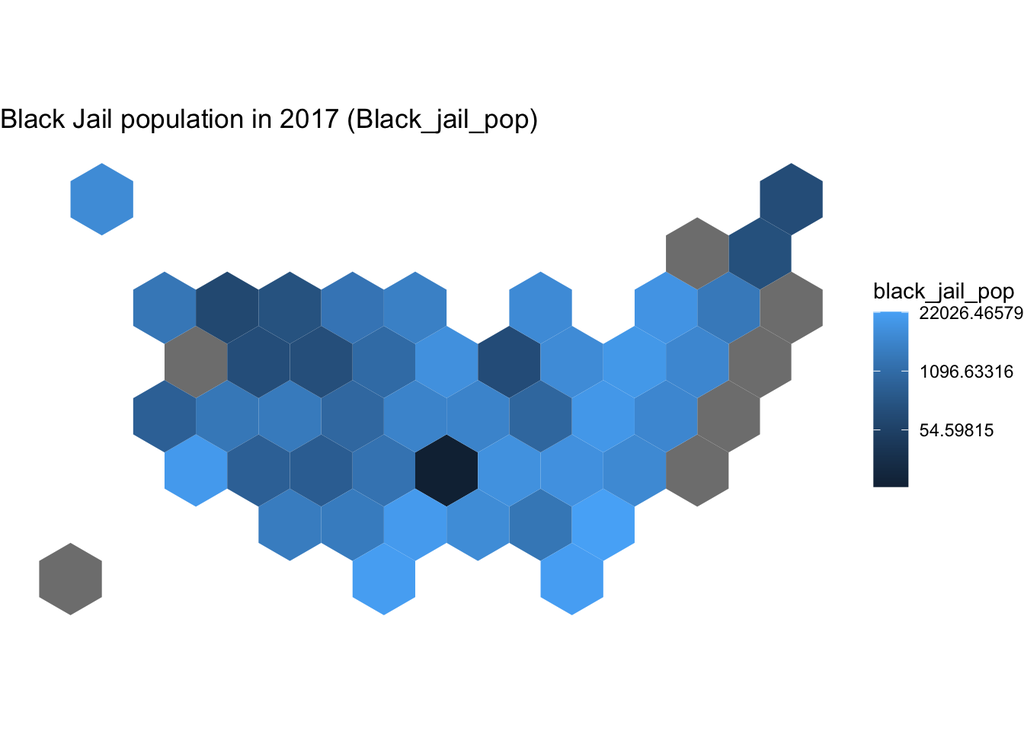